# Random Forest Analysis For Forest Fires

- Show All Code
- Hide All Code
- View Source

Author

Travis Rennacker

# Overview

**Citation:** Cortez, P., & Morais, A.. A Data Mining Approach to Predict Forest Fires Using Meteorological Data. Department of Information Systems/R&D Algoritmi Centre, University of Minho. Retrieved from http://www.dsi.uminho.pt/~pcortez

A brilliant analytical paper reviewed a large data set of fires in Portugal to find statistical relevance from various factors. This analysis will engage with the same analysis and attempt to compare tuning of the random forest aspect from Cortez et al. As noted in the above paper, the highly important environmental variables including rain, relative humidity, wind and tempurature will be used for this analysis. They will be compared with the Mean Absolute Error Metric.

**Environmental Variables used in the Random Forest:**

- (temp): Outside temperature (in ◦C)
- (rh): Outside relative humidity (in %)
- (wind): Outside wind speed (in km/h)
- (rain): Outside rain (in mm/m2)

#### library

```r
library(tidymodels)
library(tidyverse)
library(ggcorrplot)
library(knitr)
library(kableExtra)
library(here)
```

# Random Forest

#### Import Data

Import the data using read_csv(). Convert the spatial and temporal variables to factors. Log(x+1) transform the burned hectares data

```r
forest_fire_raw <- read_csv(here("data", "forestfires.csv"))

forest_fire <- forest_fire_raw |> janitor::clean_names() |> mutate(across(c(month, day), as.factor)) |> mutate(l_area = log1p(area))
```

#### Split data for analysis

```r
set.seed(9872)

forest_split <- initial_split(forest_fire, prop = 0.75) #maintains balance of data through strata across our test and train via prct of risk level

f_train <- training(forest_split)

f_test <- testing(forest_split)
```

#### Create the recipe

```r
f_recipe <- recipe(l_area ~ temp + rain + wind + rh + month, data = f_train) |>
  step_zv(all_predictors()) |>
  step_corr(all_numeric_predictors(), threshold = 0.9) #all_numeric_predictors()
```

#### Set Random Forest Parimeters

```r
rf_spec <- rand_forest(trees = 1000, #thousand trees is a good default
            mtry = tune(),
            min_n = tune())|> #hyper tuning preperation, r will get them later
  set_engine("ranger") |>
  set_mode("regression") #still want classificaiton at the end

rf_workflow <- workflow() |>
  add_recipe(f_recipe) |>
  add_model(rf_spec)
```

#### Create Grid and Tuning

```r
 #expand grid (create vectors and makes a matrix) all possible combinations of variables
rf_grid= expand_grid(
  mtry = seq(1,4, by=1),
  min_n = seq(2,8, by=2)
)

rf_res <- tune_grid(
  rf_workflow,
  resamples = vfold_cv(f_train, v = 5),
  grid = rf_grid,
  metrics = metric_set(mae),
  control=control_grid(save_workflow = TRUE)  # This is useful when finalizing the model
)
```

#### Finalize Work Flow

```r
rf_best<-select_best(rf_res,metric='mae')

rf_final<-finalize_model(rf_spec,rf_best)

# finalize workflow

final_wf <- workflow() %>%
  add_recipe(f_recipe) %>%
  add_model(rf_final)

final_res <- final_wf %>%
  last_fit(forest_split)
```

#### Predictions

```r
# Collect predictions
predictions <- final_res %>%
  collect_predictions()
```

#### Fit Best

```r
rf_best<-select_best(rf_res,metric='mae')

rf_final<-finalize_model(rf_spec,rf_best)

# finalize workflow

final_wf <- workflow() %>%
  add_recipe(f_recipe) %>%
  add_model(rf_final)

# Collect predictions
predictions <- final_res %>%
  collect_predictions()
```

#### Undo Log Transformation

```r
# Transform predictions and actual values back to non-log scale
predictions <- predictions %>%
  mutate(.pred_area = exp(.pred) - 1,
         l_area = exp(l_area) - 1)

# Calculate MAE (Mean Absolute Error) on the original scale
mae_value <- mae(predictions, truth = l_area, estimate = .pred_area)
```

```r
mae_value
```

[output not shown]

#### Table for Comparison

```r
#| fig-cap: "**Table 1.** Mae Results from Tuned Results and Paper"

# Create the data frame
mae_comparison <- data.frame(
  Model = c("Tuned RF", "Paper RF"),
  MAE_Value = c(7.28, 12.93)
)

# Print the table with pretty styling
mae_comparison %>%
  kable("html", col.names = c("Model", "MAE Value")) %>%
  kable_styling(bootstrap_options = c("striped", "hover", "responsive"),
                font_size = 14,
                full_width = F) %>%
  column_spec(1, bold = TRUE) %>%
  column_spec(2, color = "black", background = "lightgray")
```

| Model | MAE Value |
| --- | --- |
| Tuned RF | 7.28 |
| Paper RF | 12.93 |

## Tuned Random Forest Mae

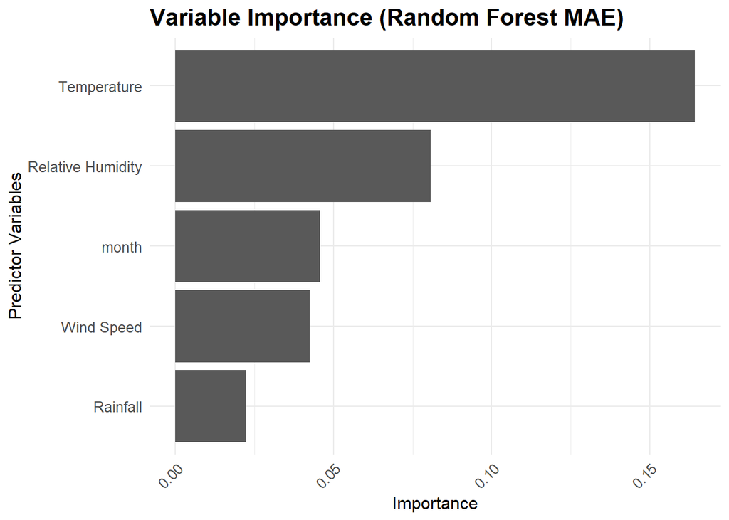

**Figure 1**, Tuned Random Forest Variable Relevance for Forest Fire Prediction.

```r
rf_final |>
  set_engine('ranger', importance = 'permutation') |>  # Permutation importance
  fit(l_area ~ ., data = juice(prep(f_recipe))) |>  # Fit model on preprocessed data
  vip::vip(geom = 'col') +  # Create bar plot for variable importance
  scale_x_discrete(labels = function(x) gsub("wind", "Wind Speed", gsub("rain", "Rainfall", gsub("temp", "Temperature", gsub("rh", "Relative Humidity", x))))) +  # Rename variables
  labs(title = "Variable Importance (Random Forest MAE)", x = "Predictor Variables") +  # Add title and axis labels
  theme_minimal() +  # Clean background
  theme(axis.text.x = element_text(angle = 45, hjust = 1),  # Rotate x-axis labels
        plot.title = element_text(size = 16, face = "bold"),  # Bold title
        axis.title = element_text(size = 12),  # Axis title size
        axis.text = element_text(size = 10))  # Axis text size
```

# Summary

- Tempurature was the most important variable with the tuned analysis
- Tuning the model created a better model
- Conceptually, all the environmental variables should help predict forest fires. According to the tuned model, tempurature and RH were the leading factors. Using these two variables from atmospheric climate projections, could lead to a greater forest fire resilence through strategic planning.